# Módulo 3

# 1 Visualização de dados com {ggplot2}

O uso de técnicas de visualização é frequente para fins de exploração, reconhecimento de padrões, estruturas, relações entre variáveis, avaliação de suposições de modelos estatísticos e na comunicação de resultados importantes de uma análise.

Quando o assunto é visualização de dados usando R, precisamos mencionar três bibliotecas importantes: `graphics`, `lattice` e `ggplot2`. O `graphics` é um pacote básico e mais primitivo para visualização em R; é muito útil porém limitado para algumas tarefas. O `lattice` foi uma das primeiras bibliotecas especializadas em gráficos que surgiu como alternativa ao `graphics`; tamanho foi seu sucesso que hoje faz parte do grupo de pacotes recomendados do R, ou seja, ao instalar o R, o `lattice` será instalado automaticamente. Já o `ggplot2` é uma alternativa mais moderna; sua sintaxe é baseada na chamada Gramática dos Gráficos em que usam-se camadas para a inclusão de elementos gráficos.

Outro tópico interessante é a visualização interativa. Tratam-se de gráficos que apresentam recursos extra ao usuário como alguma reação quando o cursor do mouse passa por pontos, opções de filtragem, zoom em áreas específicas, etc. Em geral, este tipo de visualização é usada para relatórios a serem disponibilizados na web. Alguns dos pacotes para visualização interativa são: `plotly`, `highcharter`, `googleVis`, `rCharts`, `leaflet`, `iplots`, `rgl` e `animation`. Para verificar possibilidades de gráficos que podem ser gerados em R consulte o [R Graph Gallery](https://www.r-graph-gallery.com/).

## 1.1 Um overview do {ggplot2}

O `ggplot2` é a implementação computacional em R das ideias do livro “The Grammar of Graphics” de Leland Wilkinson. A ideia é que visualizações podem ser desenvolvidas por meio de camadas. As camadas usadas são:

- Dados: onde define-se o tipo de valor e dimensões de escala.
- Variáveis visuais: define o mapeamento em variáveis visuais e controle das escalas.
- Geometrias: qual(is) representações geométricas serão usadas.
- Facetas: de que forma a visualização será dividida para exibição.
- Estatísticas: elementos de estatística ou valores calculados a serem exibidos.
- Coordenadas: sistema de coordenadas a ser usado.
- Tema: cores, demarcações, fontes, legendas, etc.

A função central do pacote é a `ggplot()`, dentro dessa função declaramos o conjunto de dados, as variáveis que queremos representar e de que forma. A partir daí começa a declaração dos elementos gráficos por meio do esquema de camadas. Para ajuda acesse o [cartão de referência de visualização de dados com o {ggplot2}](https://raw.githubusercontent.com/rstudio/cheatsheets/master/data-visualization-2.1.pdf).

Vejamos com um pouco mais de detalhes as camadas do `ggplot2` fazendo uso de um conjunto de dados que contém características de jogadores de futebol.

```r
library(tidyverse)

# Caminho para o arquivo na WEB.
url <- "http://leg.ufpr.br/~walmes/data/euro_football_players.txt"

# Leitura com `readr`.
tb <- read_tsv(file = url,
               col_names = TRUE,
               quote = "",
               comment = "#")

tb <- tb %>%
    mutate(position = str_replace(pos, "^([A-Z]+).*", "\\1"))
```

## 1.2 Camada 1: dados

Na primeira camada informamos ao `ggplot2` quais são nossos dados. Na função `ggplot()` utiliza-se o argumento `data` para declarar o conjunto de dados armazenado em um `data.frame`.

```r
ggplot(data = tb)
```

## 1.3 Camada 2: mapeamento em variáveis visuais

Para esta camada devemos nos atentar ao tipo de valor/objeto. Em nosso conjunto de dados, uma variável de interesse pode ser:

- Quantitativa: variável numérica discreta ou contínua.
- Qualitativa: variável categórica nominal ou ordinal.
- Cronológica: variável de data ou data-tempo.
- Geográfica: objetos como polígonos, por exemplo.

Precisamos entender as variáveis pois na segunda camada declaramos quais variáveis temos interesse em representar e de que forma: haverá uma variável no eixo x? Uma no eixo y? Usaremos tamanhos distintos para níveis de um determinado fator? Ou cores? Ou formas? E assim por diante.

Para declarar estas características utilizamos na função `ggplot()` o argumento mapping e, dentro deste argumento, a função `aes()` possui os argumentos: x, y, size, shape, linetype, color, fill e alpha. Utilizando estes argumentos podemos passar variáveis e depois desse mapeamento decidir que forma usaremos para representar estes dados. Com nosso conjunto de dados, alguns exemplos são:

```r
# Declarando que a variável 'position' aparecerá no eixo x
ggplot(data = tb,
       mapping = aes(x = position))

# Declarando que a variável 'cm' aparecerá no eixo x
# 'kg' no eixo y com cores distintas para a variável
# 'position'
ggplot(data = tb,
       mapping = aes(x = cm,
                     y = kg,
                     color = position))

# Declarando que a variável 'cm' aparecerá no eixo x
# 'kg' no eixo y com cores distintas para a variável
# 'position' e tamanhos distintos para a variável 'age'
ggplot(data = tb,
       mapping = aes(x = cm,
                     y = kg,
                     color = position,
                     size = age
                     ))
```

É importante notar que nestas etapas ainda não temos como um output um gráfico, ainda estamos na etapa de declaração de dados e variáveis. Começamos a ter saídas quando definimos o que fazer com a próxima camada: geometrias.

## 1.4 Camada 3: geometrias

Neste ponto, já com os dados e variáveis devidamente declarados, devemos decidir de que forma representar os dados. O pacote `ggplot2` possui uma lista considerável de geometrias disponíveis por meio de funções que complementam as informações que declaramos anteriormente. Todas as funções de geometria contam com o prefixo “geom_”. Os mais usados são `geom_bar()`, `geom_boxplot()`, `geom_density()`, `geom_histogram()` e `geom_point()`, usados para as representações gráficas mais convencionais.

```r
geoms <- ls("package:ggplot2")
ind <- grep('geom_', geoms)
geoms[ind[]]
```

```
##  [1] "geom_abline"            "geom_area"              "geom_bar"
##  [4] "geom_bin_2d"            "geom_bin2d"             "geom_blank"
##  [7] "geom_boxplot"           "geom_col"               "geom_contour"
## [10] "geom_contour_filled"    "geom_count"             "geom_crossbar"
## [13] "geom_curve"             "geom_density"           "geom_density_2d"
## [16] "geom_density_2d_filled" "geom_density2d"         "geom_density2d_filled"
## [19] "geom_dotplot"           "geom_errorbar"          "geom_errorbarh"
## [22] "geom_freqpoly"          "geom_function"          "geom_hex"
## [25] "geom_histogram"         "geom_hline"             "geom_jitter"
## [28] "geom_label"             "geom_line"              "geom_linerange"
## [31] "geom_map"               "geom_path"              "geom_point"
## [34] "geom_pointrange"        "geom_polygon"           "geom_qq"
## [37] "geom_qq_line"           "geom_quantile"          "geom_raster"
## [40] "geom_rect"              "geom_ribbon"            "geom_rug"
## [43] "geom_segment"           "geom_sf"                "geom_sf_label"
## [46] "geom_sf_text"           "geom_smooth"            "geom_spoke"
## [49] "geom_step"              "geom_text"              "geom_tile"
## [52] "geom_violin"            "geom_vline"             "update_geom_defaults"
```

Alguns exemplos utilizando nosso conjunto de dados:

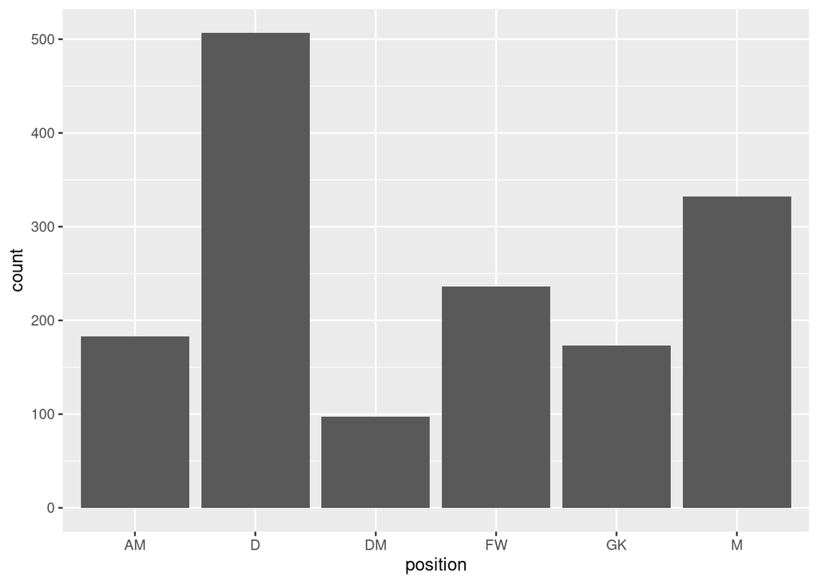

```r
# Gráfico de barras para a variável 'position'
ggplot(data = tb,
       mapping = aes(x = position)) +
    geom_bar()
```

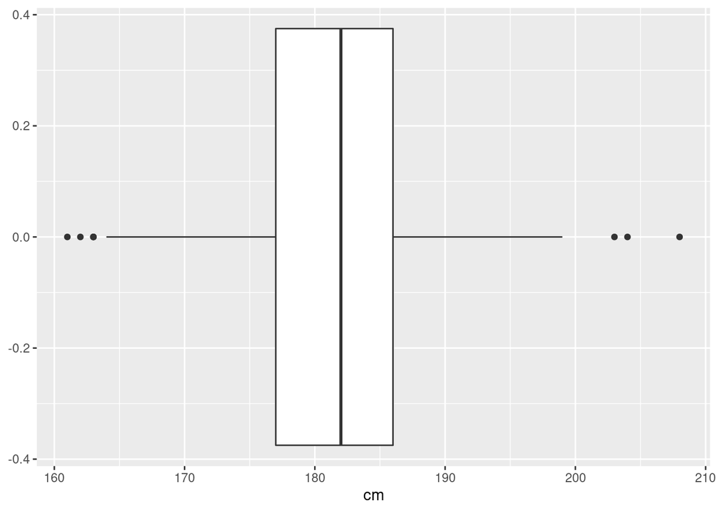

```r
# Boxplot para a variável 'cm'
ggplot(data = tb,
       mapping = aes(x = cm)) +
    geom_boxplot()
```

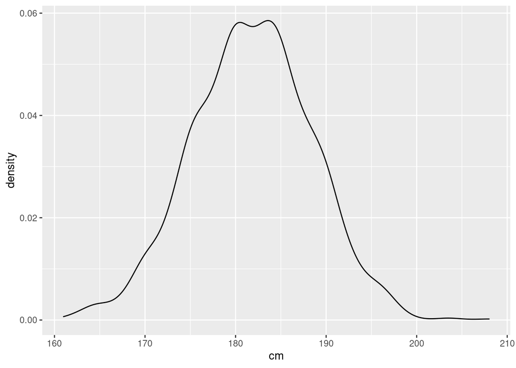

```r
# Gráfico de densidade para a variável 'cm'
ggplot(data = tb,
       mapping = aes(x = cm)) +
    geom_density()
```

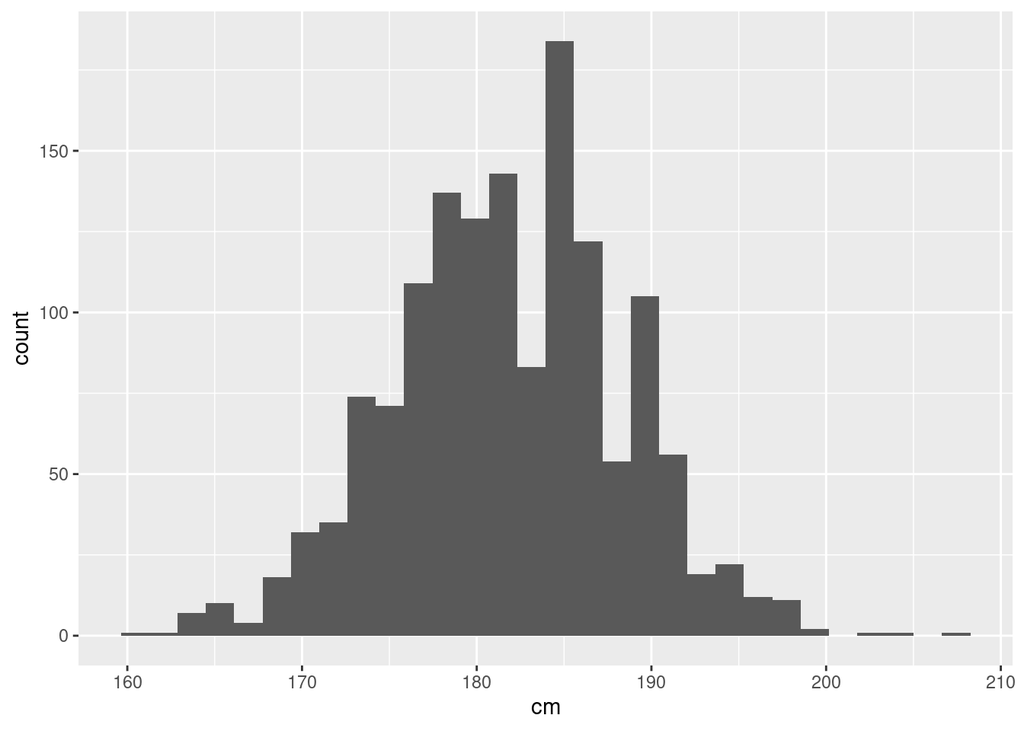

```r
# Histograma da variável 'cm'
ggplot(data = tb,
       mapping = aes(x = cm)) +
    geom_histogram()
```

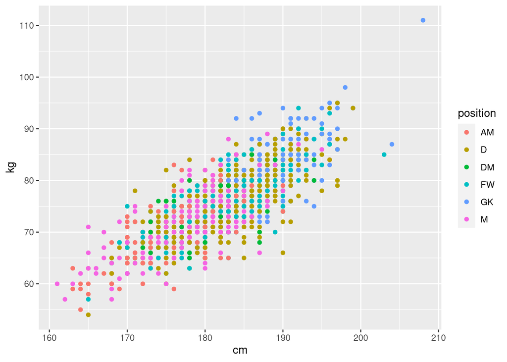

```r
# Gráfico de dispersão 'kg' em função de 'cm' com cores distintas
# para 'position'
ggplot(data = tb,
       mapping = aes(x = cm,
                     y = kg,
                     color = position)) +
    geom_point()
```

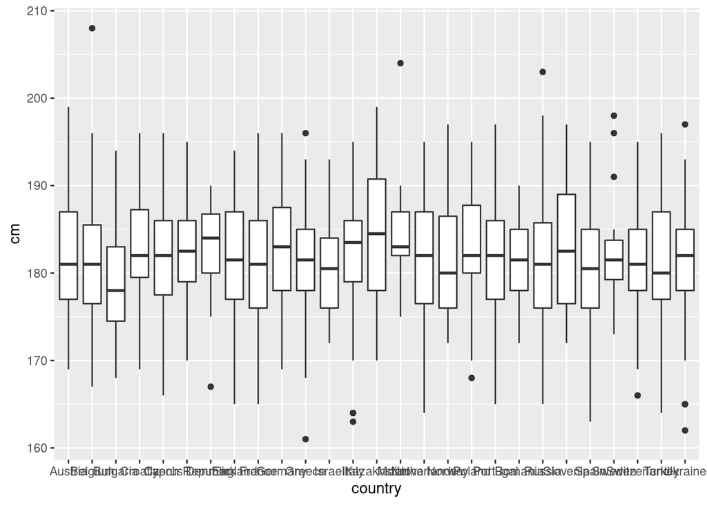

```r
# Boxplots de 'cm' para os níveis de 'country'
ggplot(data = tb,
       mapping = aes(x = country,
                     y = cm)) +
    geom_boxplot()
```

Após a camada de geometrias já temos uma representação gráfica em mãos, a partir daí o que fazemos são ajustes finos como ajuste dos eixos, manipulação de legendas e inclusão de informações que podem trazer alguma informação a mais que seja de interesse.

## 1.5 Camada 4: divisão em facetas

Em algumas situações podemos estar interessados em dividir nossa representação para níveis de uma variável. Nestes casos utilizamos a divisão em facetas. Para esta tarefa o ggplot2 possui as funções `facet_grid()`, `facet_null()` e `facet_wrap()`.

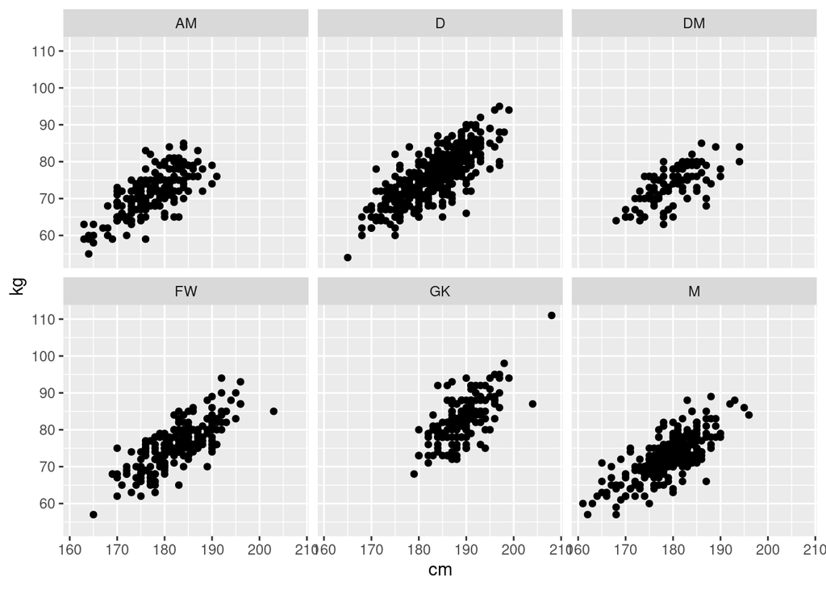

```r
# Gráfico de dispersão de 'kg' em função de 'cm' facetado por
# 'position'
ggplot(data = tb,
       mapping = aes(x = cm,
                     y = kg)) +
  geom_point() +
  facet_wrap(~position)
```

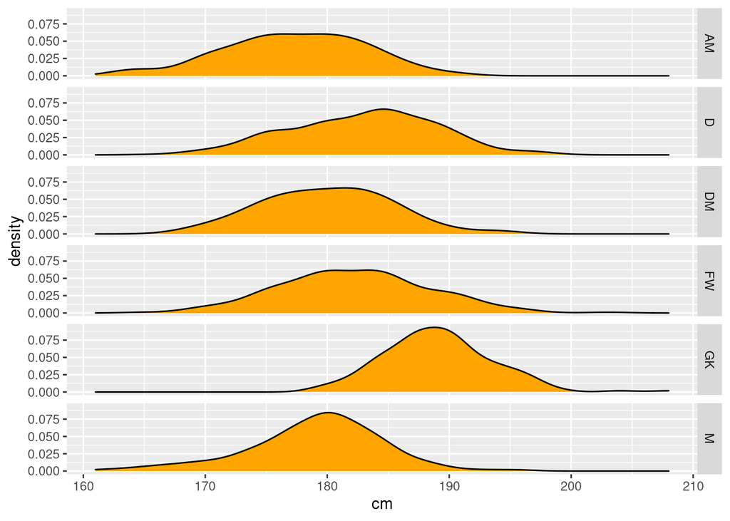

```r
# Histograma da variável 'cm' facetado por 'position'
ggplot(data = tb,
       mapping = aes(x = cm)) +
    facet_grid(facets = position ~ .) +
    geom_density(fill = "orange")
```

## 1.6 Camada 5: estatística

As funções disponíveis para a camada estatística tem o prefixo “stat_”.

```r
stats <- ls("package:ggplot2")
ind <- grep('stat_', stats)
geoms[ind[]]
```

```
##  [1] "stat_bin"               "stat_bin_2d"            "stat_bin_hex"
##  [4] "stat_bin2d"             "stat_binhex"            "stat_boxplot"
##  [7] "stat_contour"           "stat_contour_filled"    "stat_count"
## [10] "stat_density"           "stat_density_2d"        "stat_density_2d_filled"
## [13] "stat_density2d"         "stat_density2d_filled"  "stat_ecdf"
## [16] "stat_ellipse"           "stat_function"          "stat_identity"
## [19] "stat_qq"                "stat_qq_line"           "stat_quantile"
## [22] "stat_sf"                "stat_sf_coordinates"    "stat_smooth"
## [25] "stat_spoke"             "stat_sum"               "stat_summary"
## [28] "stat_summary_2d"        "stat_summary_bin"       "stat_summary_hex"
## [31] "stat_summary2d"         "stat_unique"            "stat_ydensity"
## [34] "update_stat_defaults"
```

A ideia é que estas funções realizam transformações estatísticas. Então, em vez de plotar os dados brutos, você está plotando uma transformação dos dados. O que estas funções fazem é pegar os dados brutos e gerar internamente um novo data.frame com dados transformados para fazer uma representação. Por exemplo, ao declararmos nossos dados e uma variável de interesse no eixo x, podemos usar a função `stat_ecdf()` para plotar a curva de distribuição acumulada empírica da variável. Ou seja, ggplot pega a variável, obtém os valores e os retorna em uma visualização sem que nós como usuários tenhamos que obter os valores, armazenas em um data.frame e usar um conjunto de geometrias para obter a representação de interesse.

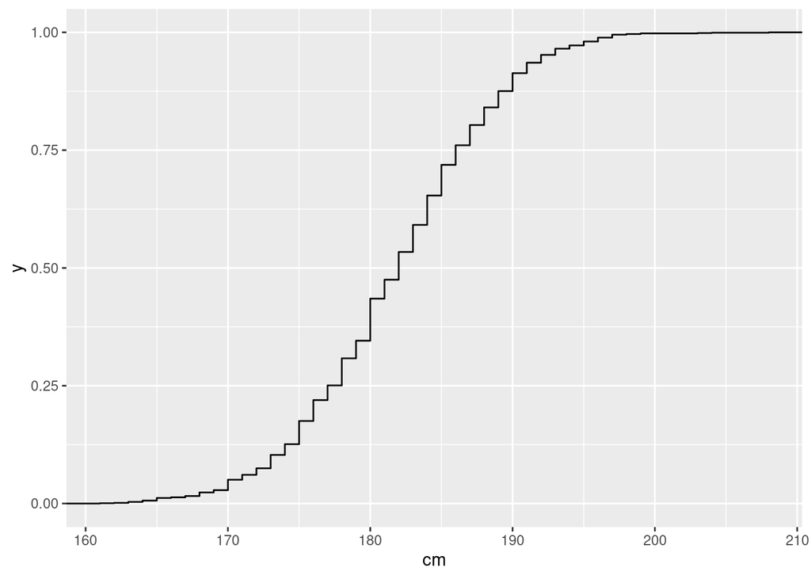

```r
ggplot(data = tb,
       mapping = aes(x = cm)) +
  stat_ecdf()
```

## 1.7 Camada 6: coordenadas

As funções disponíveis para a camada de coordenadas tem o prefixo “coord_”.

```r
coords <- ls("package:ggplot2")
ind <- grep('coord_', coords)
geoms[ind[]]
```

```
##  [1] "coord_cartesian" "coord_equal"     "coord_fixed"     "coord_flip"
##  [5] "coord_map"       "coord_munch"     "coord_polar"     "coord_quickmap"
##  [9] "coord_sf"        "coord_trans"
```

Uma das mais usadas é a `coord_flip()`, usada para transpor um gráfico.

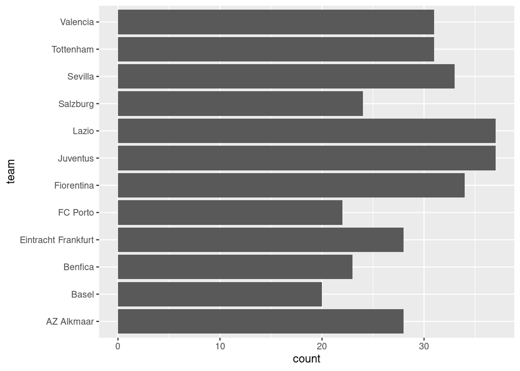

```r
ggplot(data = tb[1:348,],
       mapping = aes(x = team)) +
    geom_bar() +
    coord_flip()
```

Outra utilização frequente é o uso da função `coord_polar` para gerar gráficos de setores.

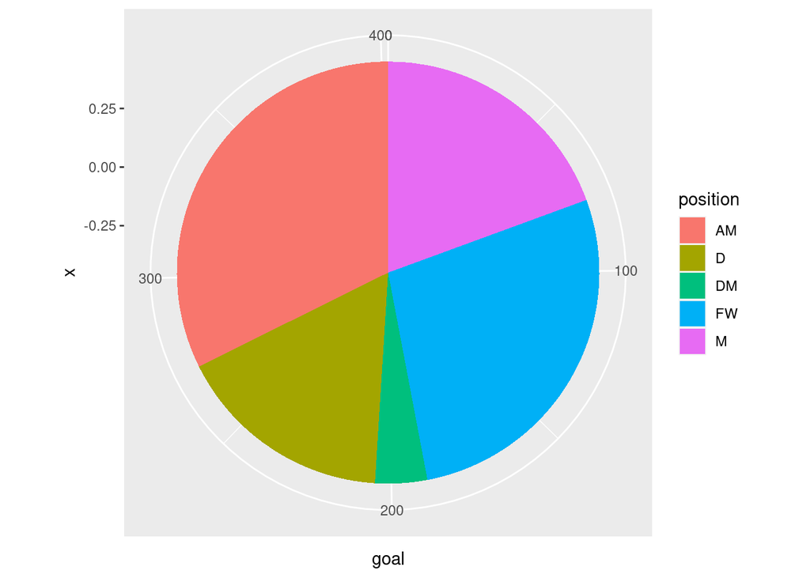

```r
ggplot(data = tb[1:348,],
       mapping = aes(x = 0,
                     y = goal,
                     fill = position)) +
  geom_col()+
  coord_polar(theta = 'y')
```

## 1.8 Camada 7: tema

A última camada é camada de temas, no ggplot as funções que definem temas começam com ‘theme_’, alguns deles são: `theme_bw()`, `theme_classic()`, `theme_dark()`, `theme_gray()`, `theme_minimal()`, `theme_void()`, etc.

```r
themes <- ls("package:ggplot2")
ind <- grep('theme_', themes)
geoms[ind[]]
```

```
##  [1] "register_theme_elements" "reset_theme_settings"
##  [3] "theme_bw"                "theme_classic"
##  [5] "theme_dark"              "theme_get"
##  [7] "theme_gray"              "theme_grey"
##  [9] "theme_light"             "theme_linedraw"
## [11] "theme_minimal"           "theme_replace"
## [13] "theme_set"               "theme_test"
## [15] "theme_update"            "theme_void"
```

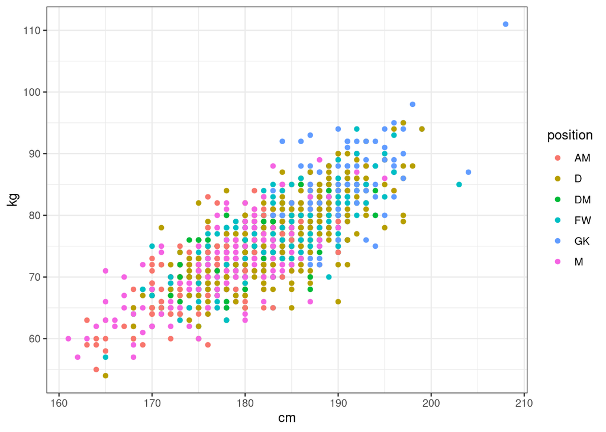

```r
# Gráfico de dispersão 'kg' em função de 'cm' com cores distintas
# para 'position'
ggplot(data = tb,
       mapping = aes(x = cm,
                     y = kg,
                     color = position)) +
    geom_point()+
  theme_bw()
```

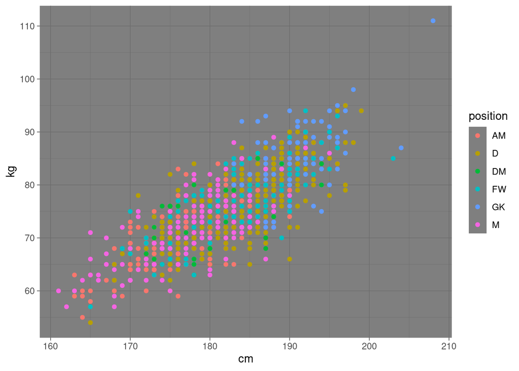

```r
# Gráfico de dispersão 'kg' em função de 'cm' com cores distintas
# para 'position'
ggplot(data = tb,
       mapping = aes(x = cm,
                     y = kg,
                     color = position)) +
    geom_point()+
  theme_dark()
```

# 2 Considerações finais

A análise exploratória de dados está presente em todos os projetos de ciência de dados. Ela serve para tirar impressões iniciais dos dados como a distribuição das variáveis, a relação entre elas, problemas com valores atípicos, etc. Uma boa análise exploratória subsidia o levantamento de hipóteses, as decisões de negócio, a engenharia de características e a construção e validação de modelos.

Dominar ferramentas para uma análise exploratória ágil é importante para celeridade dos projetos e ganho de conhecimento. Neste sentido, o R é extraordinário em termos de visualização pois possui vários pacotes e frameworks para visualização de dados. Uma delas é o `ggplot2`; como pudemos notar, é uma ferramenta altamente customizável com um número tão grande de opções que chega a ser difícil lembrar de todas as funcionalidades. Contudo existe uma infinidade de materiais para consulta.

Quando o assunto é o ggplot, o que realmente importa é o modelo mental. Tendo o objetivo claro em mente (o que fazer com cada variável, quais geometrias usar, etc) muito provavelmente existe uma forma de criar esta saída no ggplot. Para finalizar, vejamos alguns gráficos feitos com o `ggplot2` com um nível de customização um pouco maior do que o visto nos exemplos anteriores.

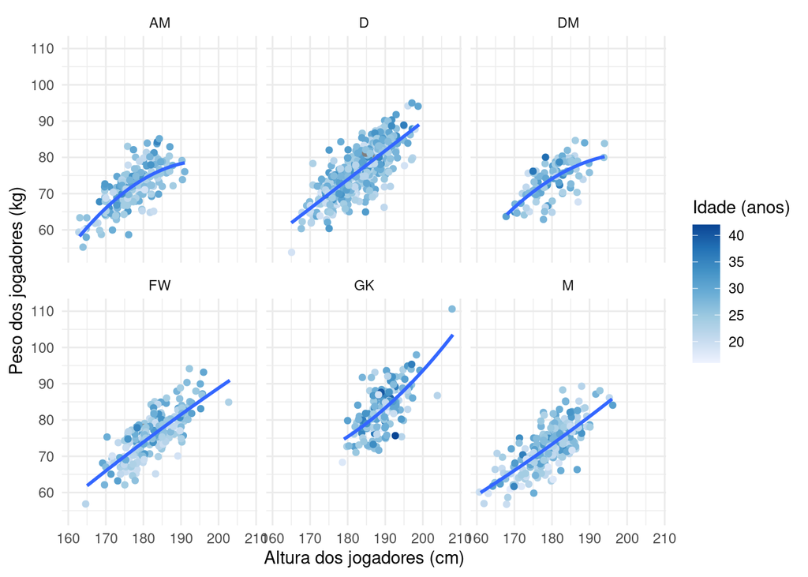

```r
ggplot(data = tb,
       mapping = aes(x = cm,
                     y = kg,
                     color = age
                     # size = age
                     )) +
    facet_wrap(facets = ~position) +
    # geom_point()
    geom_jitter() +
    # geom_smooth(se = FALSE) +
    geom_smooth(method = "lm",
                formula = y ~ poly(x,  degree = 2),
                se = FALSE) +
    scale_color_distiller(palette = 1, direction = 1) +
    labs(x = "Altura dos jogadores (cm)",
         y = "Peso dos jogadores (kg)",
         color = "Idade (anos)") +
  theme_minimal()
```

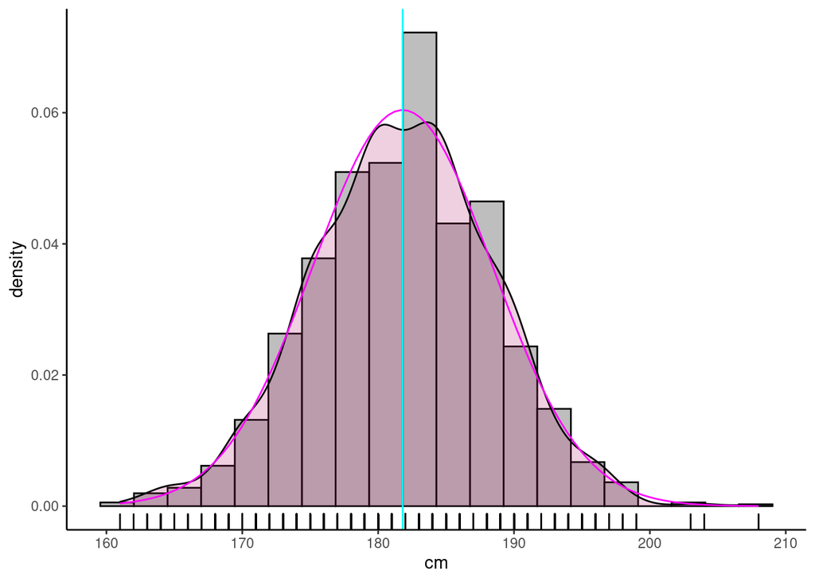

```r
m <- mean(tb$cm, na.rm = TRUE)
s <- sd(tb$cm, na.rm = TRUE)

ggplot(data = tb,
       mapping = aes(x = cm)) +
    geom_histogram(mapping = aes(y = ..density..),
                   bins = 20,
                   color = "black",
                   fill = "gray") +
    geom_density(fill = "#ab1565", alpha = 0.2) +
    stat_function(fun = dnorm,
                  args = list(mean = m, sd = s),
                  color = "magenta") +
    geom_vline(xintercept = m, color = "cyan") +
    geom_rug() +
  theme_classic()
```